# Demonstration of limmaDE2

JT Lovell

2016-04-06

The R package limmaDE2 contains a set of functions designed to make running differential expression analyses in LIMMA more user friendly. There are several functions of this package:

- `pipeLIMMA` Run analyses of differnetial expression in LIMMA.
- `makeBinarySig` Find and count the number of significantly differentially expressed genes
- `pqHists` Plot the distribution of P and FDR-corrected P (Q) values
- `voom2PCA` Conduct principal component analyses on voom (or otherwise) normalized expression matrices
- `volcanoPlot` Generate log2 foldchange vs. P-value volcano plots
- `volcanoPair` Compare two sets of log2 fold changes, colored by p-values
- `pipeDESeq2` Runs an analysis of differential expression similar to that of pipeLIMMA, except through the DESeq2 package.

## Installation

The limmaDE2 packages is not on CRAN and can only be installed from github. Make sure the `devtools` package is installed on your system. The limmaDE2 package also requires several other R packages to be installed. These packages have functions upon which limmaDE2 depends:

- `limma` contains all of the basic statistical elements that are called here.
- `SimSeq` permits simulation of RNA-seq data
- `plyr` summarize and manipulate lists and dataframes
- `vegan` some distance-based methods
- `Heatplus` heatmap plotting
- `topGO` gene ontology (GO) analysis
- `qvalue` fdr-corrected p-values

If these are not on your system, run the following command in R:

```r
install.packages(c("plyr","vegan"))

source("https://bioconductor.org/biocLite.R")
biocLite(c("limma","SimSeq","Heatplus","topGO","qvalue"))
```

Also, for this tutorial, you will need a few additional packages.

```r
install.packages(c("ggplot2","reshape2","hexbin"))
```

To install limmaDE2:

```r
library(devtools)
install_github("jtlovell/limmaDE2")
library(limmaDE2)
```

A data package `PhyGenomicsData.PV2016` accompanies limmaDE2 and contains datasets needed to run this tutorial.

```r
install_github("jtlovell/PhyGenomicsData.PV2016")
library(PhyGenomicsData.PV2016)
```

Load all packages that will be needed for the tutorial:

```r
library("ggplot2")
library("reshape2")
library("hexbin")
```

## Importing data and checking

For limmaDE2 to work, two matrices are needed: - `counts`: Raw transcript abundance counts - `info`: Experimental design information These two matrices must match exactly, where each row in the `info` matrix corresponds to each column in `counts`. For best performance, the name of each gene should be stored in the rownames of the counts matrix.

```r
data(info12)
data(counts12)
```

Here, info12 and counts12 come from a dataset where the AP13 switchgrass genotype was cloned and planted under a rain-exclusion shelter. Six treatment levels were applied. Relevant information about this experiment is in a manuscript in review. Contact `johntlovell@gmail.com` for more information.

In all statistical analyses, it is important to set the levels of the experimental factors. This is esspecially true in linear modelling, such as limma, where levels are tested against the base level. Here, we set the “high” treatment as the base.

```r
info12$Treatment <- factor(info12$Treatment,
                           levels = c("high", "75th", "ambient", "mean", "25th", "low"))
```

## Basic analysis of differential expression

For the purposes of this tutorial, we will use only the first 1000 genes in the counts matrix. This will speed up all downstream analyses.

```r
counts12<-counts12[1:1000,]
```

To test the plasticity (differential expression) of all genes across the six treatments:

```r
stats <- pipeLIMMA(counts = counts12,
                   info = info12,
                   block = NULL,
                   formula = "~ Treatment")
```

```
## calculating normalization factors ...
## running voom normalization correcting for quality weights ...
## fitting linear model ...
## processing statistics and calculating q-values ...
```

`pipeLIMMA` returns three elements: `stats`, `voom` and `fstats`. These are the statistical output of the limma functions: `eBayes`, `voom` and `topTableF`. Inspect the top few rows and columns of each.

- `stats`: eBayes linear model statistics

  | gene |  | sigma s | 2.post | Amean | Fstat F | pvalue |
  | --- | --- | --- | --- | --- | --- | --- |
  | Pavir.Aa00698.1.axpr.g | Pavir.Aa00698.1.axpr.g | 0.8702496 | 0.7661150 | 8.283666 | 0.4603757 | 0.8034730 |
  | Pavir.Aa00699.1.axpr.g | Pavir.Aa00699.1.axpr.g | 0.8300969 | 0.7129438 | 10.805598 | 2.3024774 | 0.0608975 |
  | Pavir.Aa01081.1.axpr.g | Pavir.Aa01081.1.axpr.g | 0.9231576 | 0.8400115 | 7.747147 | 1.9156119 | 0.1111444 |
  | Pavir.Aa01130.1.axpr.g | Pavir.Aa01130.1.axpr.g | 1.0723255 | 1.0718295 | 6.699065 | 1.5981084 | 0.1807545 |
  | Pavir.Aa01314.1.axpr.g | Pavir.Aa01314.1.axpr.g | 1.0386000 | 1.0163854 | 9.271852 | 2.8325570 | 0.0266506 |
  | Pavir.Aa01801.1.axpr.g | Pavir.Aa01801.1.axpr.g | 1.3522369 | 1.6003693 | 6.958654 | 2.8946558 | 0.0242010 |

- `voom`: normalized expression matrix

  |  | A461 | A526 | A581 | A645 | A668 | A705 |
  | --- | --- | --- | --- | --- | --- | --- |
  | Pavir.Aa00698.1.axpr.g | 7.715750 | 8.836836 | 8.903393 | 8.250583 | 8.969640 | 5.837053 |
  | Pavir.Aa00699.1.axpr.g | 10.277253 | 11.030846 | 10.249843 | 9.898281 | 10.978410 | 11.490495 |
  | Pavir.Aa01081.1.axpr.g | 7.516441 | 6.599796 | 8.166427 | 6.665621 | 7.312527 | 5.837053 |
  | Pavir.Aa01130.1.axpr.g | 7.971007 | 6.962366 | 7.474550 | 6.665621 | 7.518978 | 7.059446 |
  | Pavir.Aa01314.1.axpr.g | 9.300712 | 9.942189 | 8.632091 | 10.226336 | 10.506905 | 7.952530 |
  | Pavir.Aa01801.1.axpr.g | 7.619534 | 7.879904 | 8.166427 | 8.736010 | 8.135650 | 8.775653 |

- `fstats`: F-statistics for each factor in the model, in this case, just treatment

| gene | Treatment_F | Treatment_P.Value | Treatment_Q.Value |
| --- | --- | --- | --- |
| Pavir.Aa00698.1.axpr.g | 0.4603757 | 0.8034730 | 0.4714395 |
| Pavir.Aa00699.1.axpr.g | 2.3024774 | 0.0608975 | 0.1349364 |
| Pavir.Aa01081.1.axpr.g | 1.9156119 | 0.1111444 | 0.1829070 |
| Pavir.Aa01130.1.axpr.g | 1.5981084 | 0.1807545 | 0.2233776 |
| Pavir.Aa01314.1.axpr.g | 2.8325570 | 0.0266506 | 0.0921204 |
| Pavir.Aa01801.1.axpr.g | 2.8946558 | 0.0242010 | 0.0870617 |

## Count the number of significantly differentially expressed genes

The function `makeBinarySig` looks for a provided string (e.g. “Q.Value”) and outputs a matrix with whether or not those columns have values <= the provided alpha

```r
lmStats <- stats$stats
sigs <- makeBinarySig(lmStats, what = "Qvalue", alpha = 0.05)
```

```
## ebayesQvalue_Treatment75th   0
## ebayesQvalue_Treatmentambient    74
## ebayesQvalue_Treatmentmean   49
## ebayesQvalue_Treatment25th   37
## ebayesQvalue_Treatmentlow    65
```

## Make a volcano plot of the results

Volcano plots are a good way to look at the differences between two experimental levels. Here, we compare the extent of differential expression between the “high” treatment to the “low” treatment.

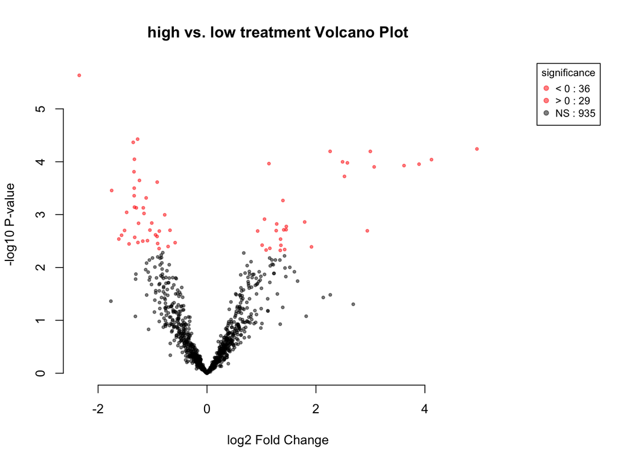

```
##       sig
## updown FALSE TRUE
##   down   480   36
##   up     455   29
```

```r
with(lmStats, volcanoPlot(pval = ebayesPvalue_Treatmentlow,
                          lfc = Treatmentlow_logFC,
                          sig = ebayesQvalue_Treatmentlow,
                          main = "high vs. low treatment Volcano Plot",
                          bty = "n"))
```

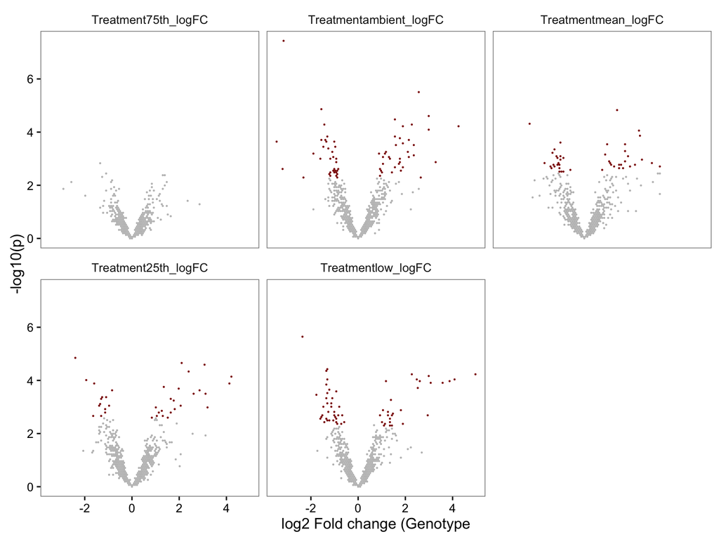

```r
lmStatsM.long.lfc <- melt(lmStats,
                          measure.vars = colnames(lmStats)[grep("logFC", colnames(lmStats))])
lmStatsM.long.p <- melt(lmStats,
                        measure.vars = colnames(lmStats)[grep("Pvalue", colnames(lmStats))])
lmStatsM.long.q <- melt(lmStats,
                        measure.vars = colnames(lmStats)[grep("Qvalue", colnames(lmStats))])
toHex<-data.frame(lmStatsM.long.lfc[, c("variable","value")],
                  lmStatsM.long.p[, "value"],
                  lmStatsM.long.q[, "value"])
colnames(toHex) <- c("contrast","lfc","p","q")
ggplot(toHex, aes(x = lfc, y=-log10(p), fill = ifelse(q <= 0.05,"sig","NS"))) +
  stat_binhex(bins=100) +
  facet_wrap(~contrast) +
  scale_fill_manual(values=c("grey","darkred"), guide = FALSE) +
  labs(x = "log2 Fold change (Genotype") +
  theme_bw() +
  theme(panel.grid.major = element_blank(),
        panel.grid.minor = element_blank(),
        strip.background = element_blank())
```

## Calculating differential expression with a blocking factor

Often, it is important to correct for spatial designs, or repeated measures on single individuals. In this case, we have a split plot design, so we can correct for this treatment the sub block as a blocking variable

```r
stats <- pipeLIMMA(counts = counts12,
                   info = info12,
                   block = as.factor(info12$Sub_Block),
                   formula = "~ Treatment")
```

```
## calculating normalization factors ...
## running voom normalization correcting for quality weights ...
## calculating duplicate correlation among replicates ...
## fitting linear model ...
## processing statistics and calculating q-values ...
```

```r
voom <- stats$voom[["E"]]
```

Such approaches can reduce the residual variance and improve the ability to detect differential expression. Here is the original model n. significance:

```r
sigs <- makeBinarySig(lmStats, what = "Qvalue", alpha = 0.05)
```

```
## ebayesQvalue_Treatment75th   0
## ebayesQvalue_Treatmentambient    74
## ebayesQvalue_Treatmentmean   49
## ebayesQvalue_Treatment25th   37
## ebayesQvalue_Treatmentlow    65
```

And with the sub-plot blocking factor:

```r
lmStats.block <- stats$stats
sigs <- makeBinarySig(lmStats.block, what = "Qvalue", alpha = 0.05)
```

```
## ebayesQvalue_Treatment75th   0
## ebayesQvalue_Treatmentambient    77
## ebayesQvalue_Treatmentmean   51
## ebayesQvalue_Treatment25th   39
## ebayesQvalue_Treatmentlow    67
```

## Calculating differential expression using specific contrasts

Sometimes, it may make more sense to use specific contrasts to test for differential expression. For example, let’s say we are interested in how different the “high” and “75th” treatments are from the “mean” and “low” treatments. First, we need to construct a contrast matrix. In this case, without an intercept. Also, it is good practice to make the column names as short as possibe, while not starting with a number.

```r
design <- with(info12, model.matrix(~ 0 + Treatment))
colnames(design) <- gsub("Treatment", "f", colnames(design))
contrast.matrix <- makeContrasts(
  f75th - flow, fhigh - flow,  f75th-fmean, fhigh-fmean,
  levels = design)
```

Then, fit the model with a contrast matrix as the design, overriding the formula argument.

```r
stats <- pipeLIMMA(counts = counts12,
                   info = info12,
                   block = info12$Sub_Block,
                   design = design,
                   contrast.matrix = contrast.matrix)
```

```
## calculating normalization factors ...
## running voom normalization correcting for quality weights ...
## calculating duplicate correlation among replicates ...
## fitting model to contrast matrix ...
## processing statistics and calculating q-values ...
```

```r
lmStats.contrast <- stats$stats
sigs <- makeBinarySig(lmStats.contrast, what = "Qvalue", alpha = 0.05)
```

```
## ebayesQvalue_f75th...flow    0
## ebayesQvalue_fhigh...flow    67
## ebayesQvalue_f75th...fmean   0
## ebayesQvalue_fhigh...fmean   51
```

## Principal component analysis of gene expression

It is often a good idea to get an idea of how the individuals (libraries) are structured - how similar are they to eachother. Principal component analyses allow for this kind of inference.

```r
pca12 <- voom2PCA(v=voom, info = info12, ids = info12$id, pcas2return = 6)
```

[figure not shown]

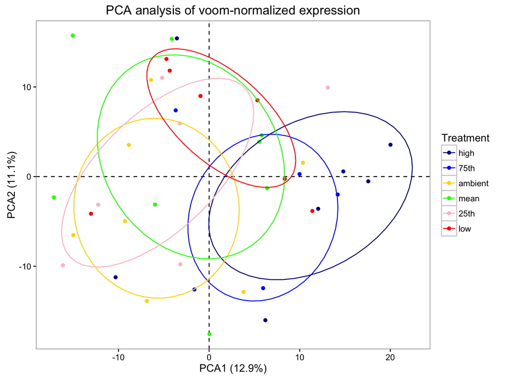

```r
pca12.var <- pca12[[2]]
pca12 <- pca12[[1]]
gcols <- c("darkblue", "blue", "gold", "green", "pink", "red")
ggplot(pca12, aes(x = PC1, y = PC2, col = Treatment)) +
  geom_vline(xintercept = 0, lty = 2)+
  geom_hline(yintercept = 0, lty = 2)+
  geom_point() +
  theme_bw() +
  scale_color_manual(values = gcols) +
  scale_shape_manual(values = gpchs) +
  theme(panel.grid.major = element_blank(),
        panel.grid.minor = element_blank(),
        strip.background = element_blank()) +
  stat_ellipse(level = 0.50) +
  labs(x = paste("PCA1 (", pca12.var[1],"%)", sep = ""),
       y = paste("PCA2 (", pca12.var[2],"%)", sep = ""),
       title = "PCA analysis of voom-normalized expression")
```

For more information, visit lovelleeb.weebly.com/analytics